# Standardising app development - phsshiny

uRos 2026

Standardising app development - phsshiny

Ciara Gribben | Bateman McBride | Russell McCreath

PHS Data Science

[figure not shown]

## 👋 Hello / Bonjour

she/her  
Ciara Gribben

Senior Analyst

Vaccine Analytics

ciara.gribben@phs.scot

ciarag01

he/him  
Russell McCreath

Senior Analyst

Data Science

russell.mccreath@phs.scot

rmccreath

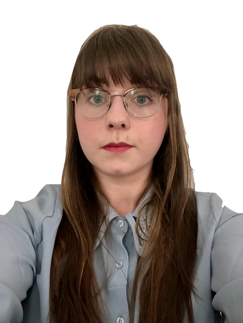

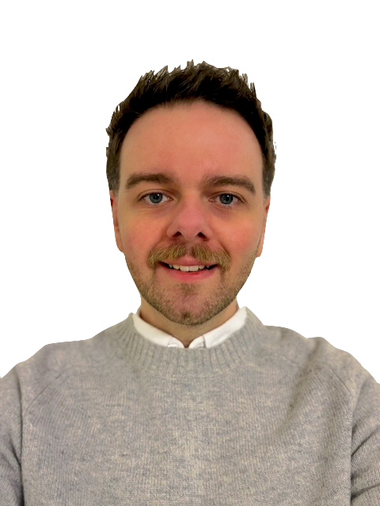

## Public Health Scotland (PHS)

As the national public health body for Scotland, we produce:

**300+ statistical publications** (in 2026)

**~150 linked active public dashboards**/apps<sup>1</sup>

+ internal management information and bespoke reporting.

This covers **~40 health topics** from

**~30 service areas**, by **~600 data/analytical staff**.

[figure not shown]

Source: scotland.shinyapps.io, as at 12 November 2026.

## App estate size by year

[figure not shown]

~600

apps deployed by PHS in the public domain<sup>2</sup>

With demand overtaking the organisation’s ability to implement core supports

Source: scotland.shinyapps.io, as at 12 November 2026. *2026 is a partial year.

## What makes a PHS product?

[figure not shown]

Statistics, charts, narrative

Accredited official statistics producer, PHS fulfils statutory benchmarks for trustworthiness, quality, and public value<sup>3</sup>

PHS is identified as “an authoritative source of evidence, as [an] official body yet independent from national and local government.”<sup>4</sup>

More than 3 in 4 report that PHS information is of high quality and meets their needs<sup>5</sup>

<sup>3</sup> PHS – About our statistics | <sup>4</sup> https://doi.org/10.1016/j.jth.2026.102368 | <sup>5</sup> PHS - Improving our statistics survey

## What’s behind a PHS product?

[figure not shown]

Statistics, charts, narrative

[figure not shown]

Accessibility

[figure not shown]

Governance

[figure not shown]

Metadata

[figure not shown]

Content

[figure not shown]

Data

[figure not shown]

Design

[figure not shown]

QA

[figure not shown]

Software

[figure not shown]

365

compliance requirements across 8 categories, identified in the research phase

## App estate

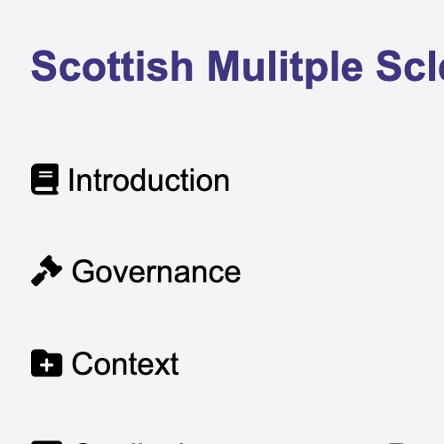

[figure not shown]

[figure not shown]

[figure not shown]

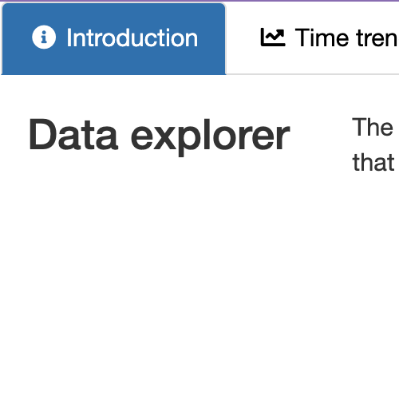

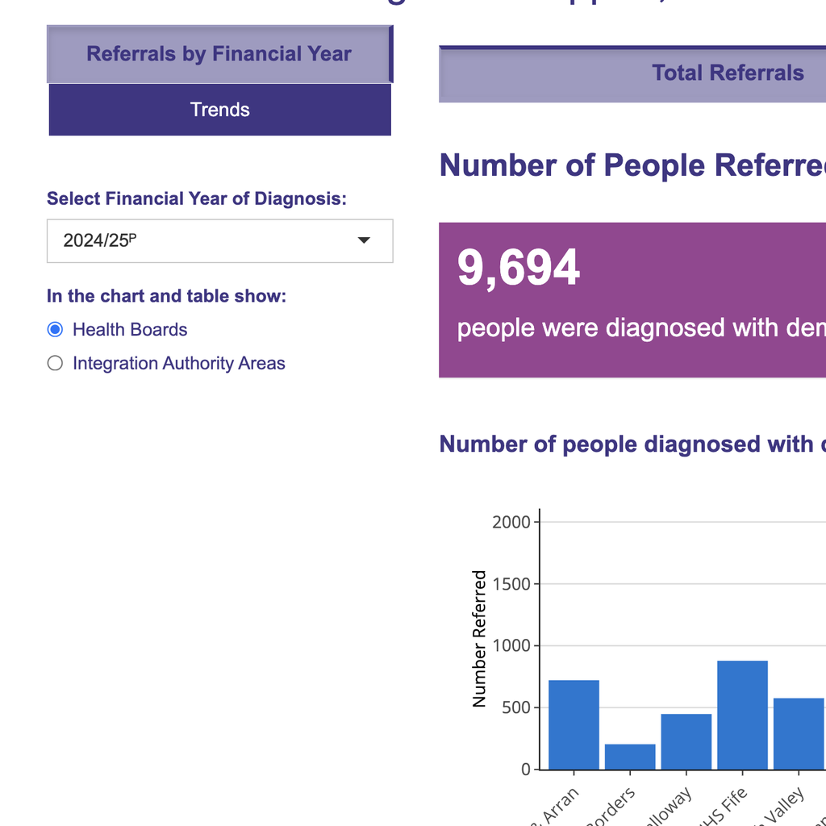

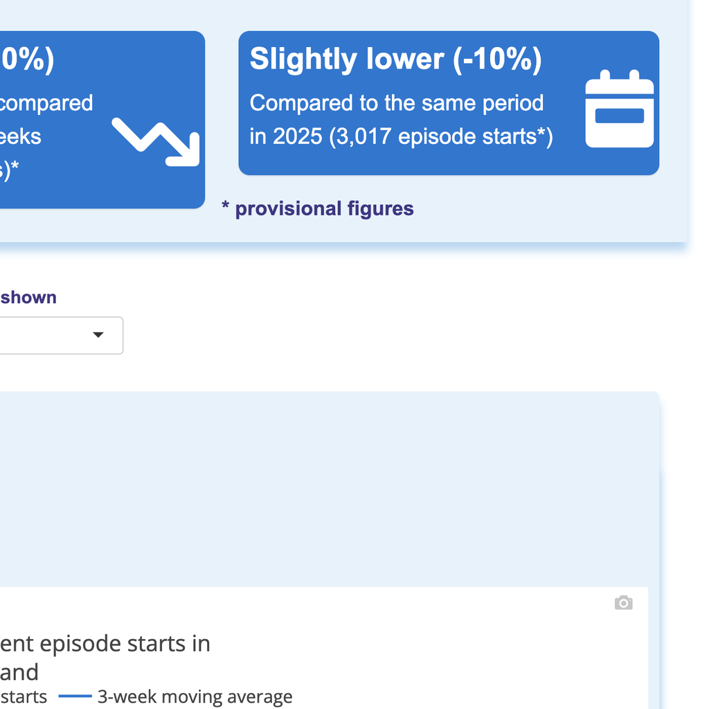

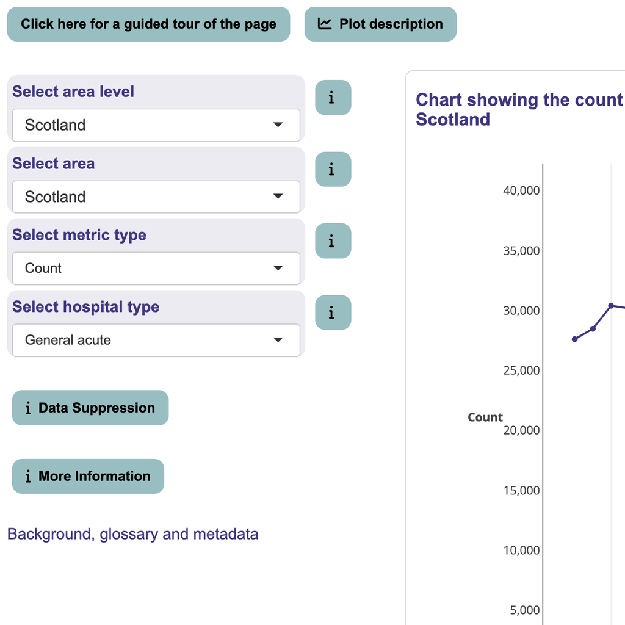

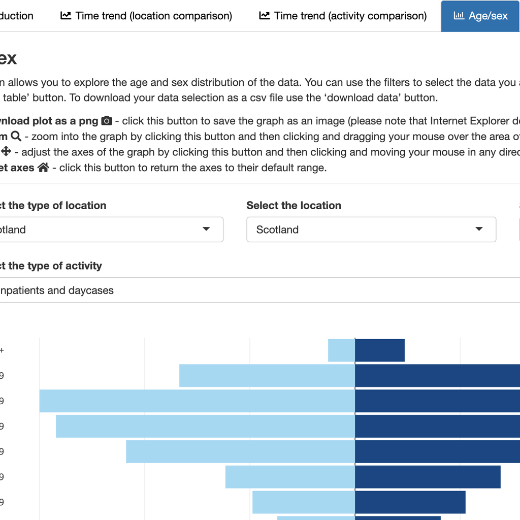

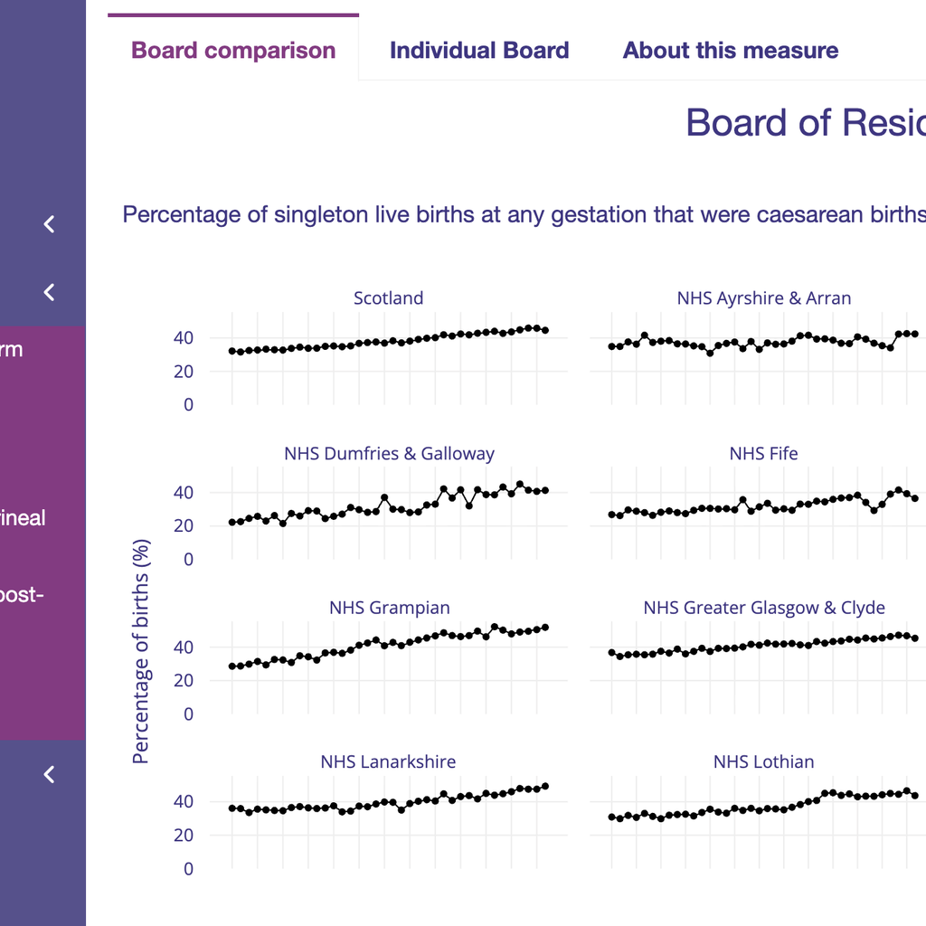

## App state

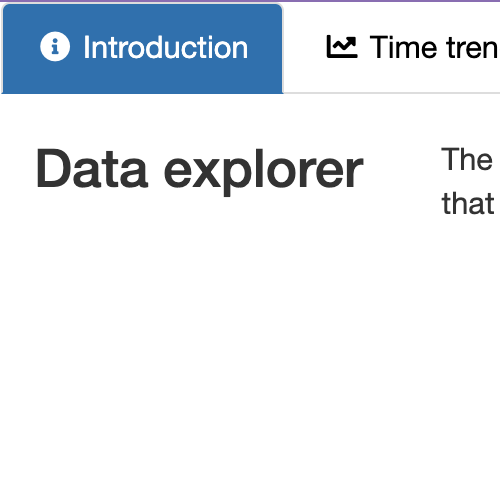

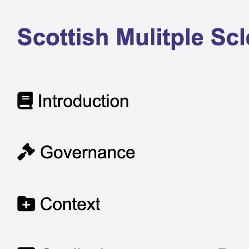

[figure not shown]

[figure not shown]

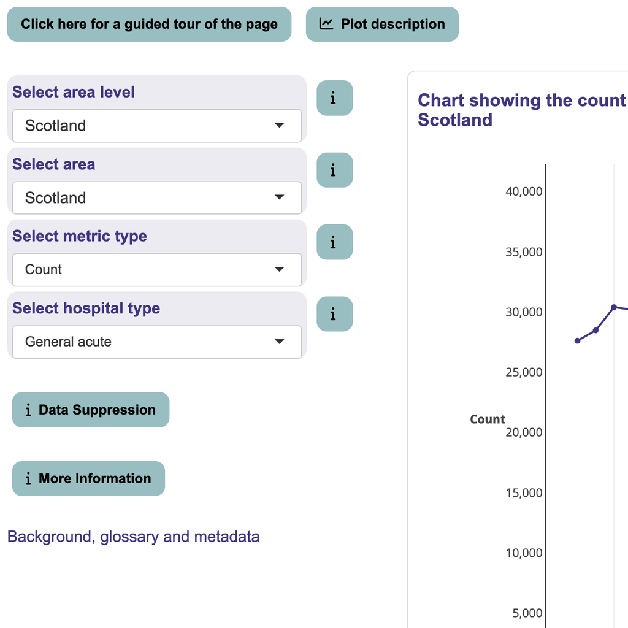

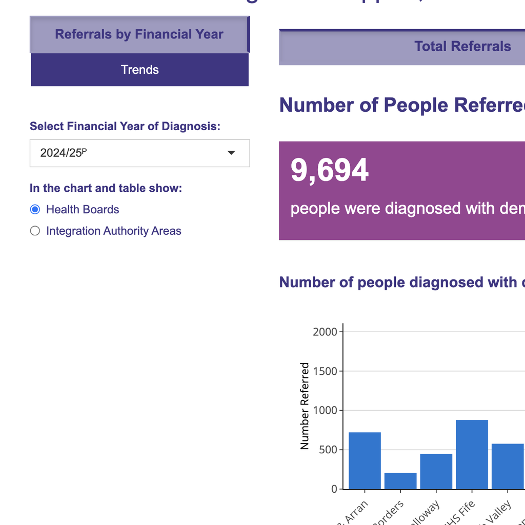

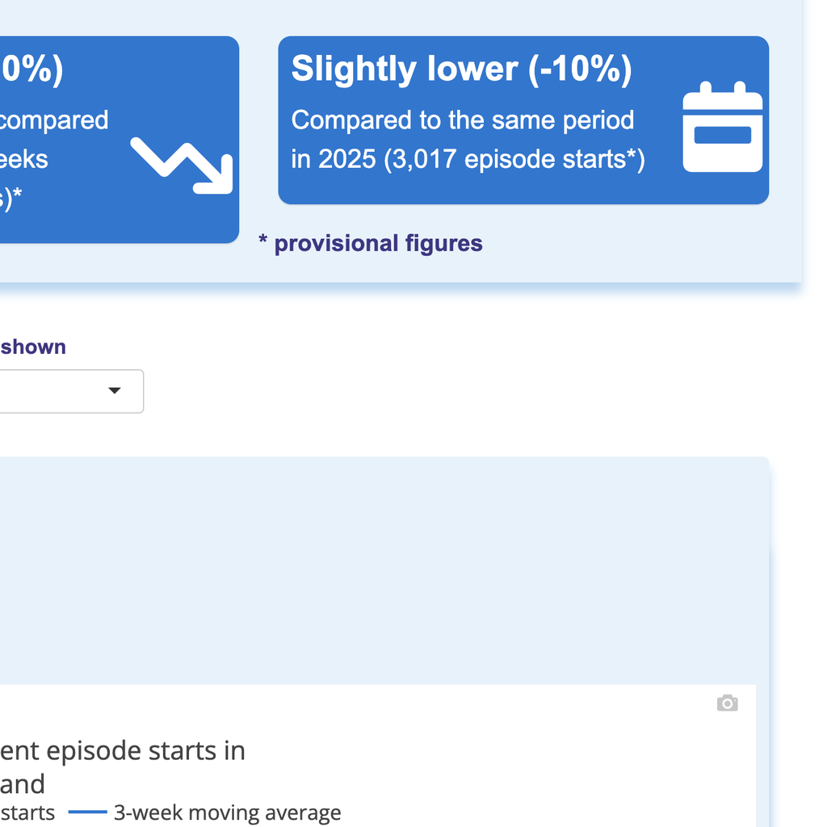

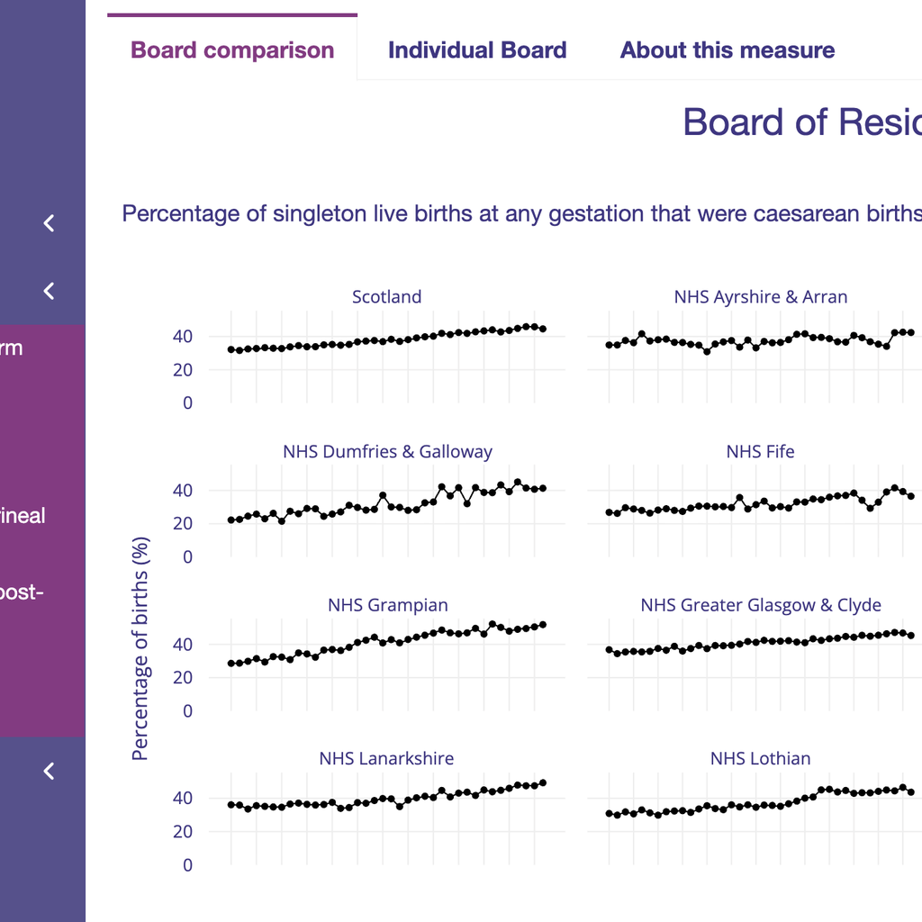

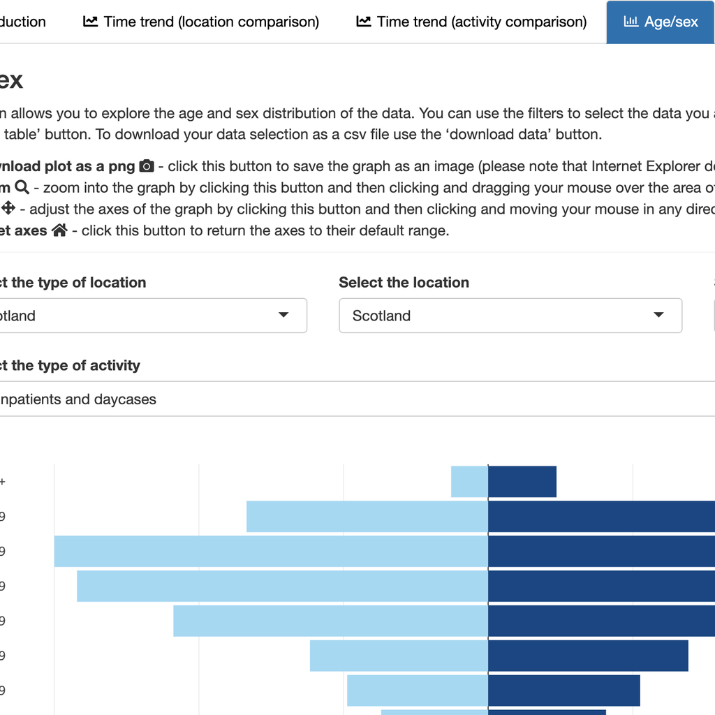

[figure not shown]

Even when individually fine, inconsistency impacts usability and reputation across the collective.